# Setup

In this lesson on basic data visualisation we will use data from the `employees` table of the 'OmniCorp' database we used in the lab yesterday, just to give us more interesting graps to look at!

```python
import pandas as pd
employees = pd.read_csv('../../data/omni_employees.csv', parse_dates=['start_date'])
employees
```

|  | id | first_name | last_name | email | department | team_id | grade | country | fte_hours | pension_enrol | salary | pay_detail_id | start_date |
| --- | --- | --- | --- | --- | --- | --- | --- | --- | --- | --- | --- | --- | --- |
| 0 | 1 | Ibbie | Roscrigg | iroscrigg0@google.fr | Legal | 9 | 0.0 | Nigeria | 0.25 | Yes | 97667.0 | 1 | 2014-12-25 |
| 1 | 2 | Sylas | Smallcomb | NaN | Training | 3 | 0.0 | Macedonia | 0.75 | No | 48556.0 | 2 | 1991-08-01 |
| 2 | 4 | Osmund | Kittel | okittel3@bloomberg.com | Legal | 10 | 0.0 | United Kingdom | 1.00 | Yes | 51200.0 | 4 | 2007-09-06 |
| 3 | 5 | Feodora | Dumingos | fdumingos4@bandcamp.com | Engineering | 2 | 0.0 | Indonesia | 0.50 | Yes | 60460.0 | 5 | 1990-03-28 |
| 4 | 6 | Peter | de Vaen | pdevaen5@mail.ru | Product Management | 2 | 1.0 | Greece | 0.50 | No | 32060.0 | 6 | 1992-06-30 |
| ... | ... | ... | ... | ... | ... | ... | ... | ... | ... | ... | ... | ... | ... |
| 995 | 997 | Carlina | Pirot | cpirotro@archive.org | Business Development | 2 | 0.0 | China | 1.00 | No | 63189.0 | 997 | 2018-08-30 |
| 996 | 998 | Wileen | Skones | wskonesrp@hhs.gov | Accounting | 4 | 0.0 | Uganda | 0.25 | Yes | 81734.0 | 998 | 2000-11-26 |
| 997 | 999 | Willy | Dulake | wdulakerq@webeden.co.uk | Business Development | 9 | 0.0 | Colombia | 0.25 | No | 21590.0 | 999 | 2018-08-01 |
| 998 | 1000 | Maribelle | Rotge | mrotgerr@google.co.uk | Research and Development | 5 | 0.0 | Brazil | 0.50 | Yes | 62531.0 | 1000 | 2019-03-09 |
| 999 | 3 | Saleem | Adame | sadame3@utexas.edu | Services | 9 | 0.0 | Portugal | 0.25 | Yes | 91749.0 | 3 | 1999-10-09 |

1000 rows × 13 columns

Looking at `.info()`, we see that the conversion has been successful

```python
employees.info()
```

```
<class 'pandas.core.frame.DataFrame'>
RangeIndex: 1000 entries, 0 to 999
Data columns (total 13 columns):
 #   Column         Non-Null Count  Dtype
---  ------         --------------  -----
 0   id             1000 non-null   int64
 1   first_name     974 non-null    object
 2   last_name      1000 non-null   object
 3   email          878 non-null    object
 4   department     1000 non-null   object
 5   team_id        1000 non-null   int64
 6   grade          980 non-null    float64
 7   country        1000 non-null   object
 8   fte_hours      1000 non-null   float64
 9   pension_enrol  958 non-null    object
 10  salary         935 non-null    float64
 11  pay_detail_id  1000 non-null   int64
 12  start_date     926 non-null    datetime64[ns]
dtypes: datetime64[ns](1), float64(3), int64(3), object(6)
memory usage: 101.7+ KB
```

# `seaborn`

We're going to use a package called `seaborn` for visualisation. This works 'on top' of the base package `matplotlib` and offers enhanced functionality and improved graphics. It's possible to produce advanced and slick looking visualisations in `seaborn` with fairly simple code!

Let's load the package (we'll load `matplotlib.pyplot` as well, as we will want to alter some of the default settings for plotting

```python
import matplotlib.pyplot as plt
import seaborn as sns
```

Now, let's set the default figure size (inches), resolution (in 'dots per inch' DPI) and font size

```python
plt.rcParams['figure.figsize'] = [6, 3]
plt.rcParams['figure.dpi'] = 200
plt.rcParams['font.size'] = 10
```

Neat, we're ready to go!

# Scatter plots

Scatter plots and line plots are often the first choice when you are plotting one **continuous** variable against another **continuous** variable. Let's see an example, plotting how `salary` has changed with `start_date`

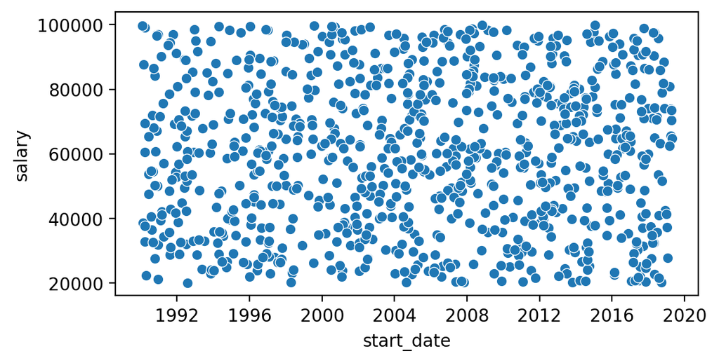

```python
scatter = sns.scatterplot(data=employees, x='start_date', y='salary')
```

We see that `salary` has maintained a fairly uniform spread across the years (this data is clearly synthesised: this wouldn't be true in reality of course). One nice feature of `seaborn` is that it is easy to 'split' the data in such plots by a third variable. Let's colour the dots by the `pension_enrol` status of each employee

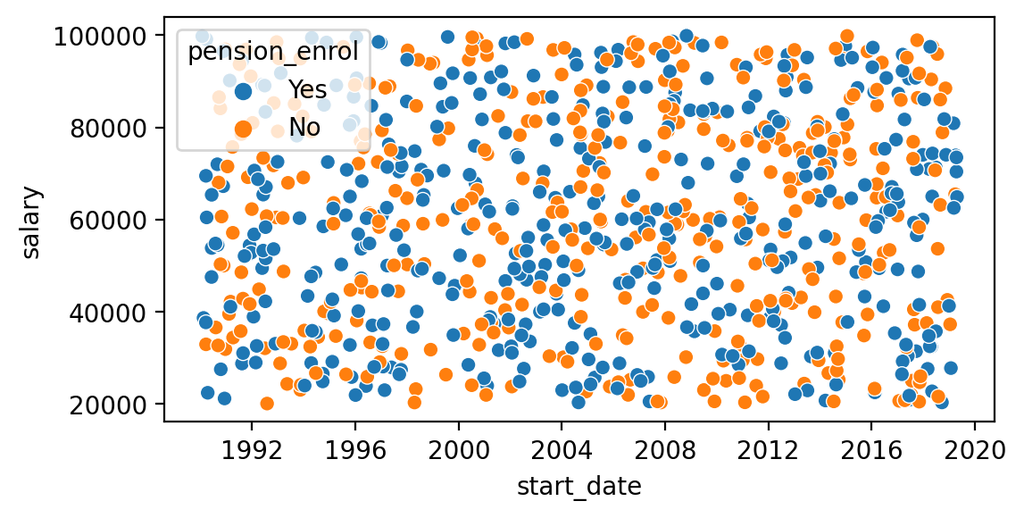

```python
scatter = sns.scatterplot(data=employees, x='start_date', y='salary', hue='pension_enrol')
```

**Task - 5 mins**

- Change the code for the visualisation above so that we limit employees to just those in the 'Accounting' department [**Hint** - try `.loc[]` or `.query()`].
- Create a similar visualisation for 'Accounting' employees using the `sns.jointplot()` function. What extra features does it add to the simple scatterplot, and how do you interpret them?

**Solution**

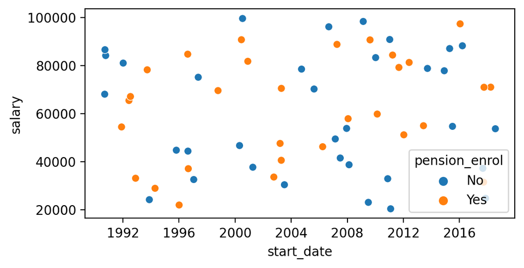

```python
# use .query() to select Accounting employees (use .loc[] below)
scatter = sns.scatterplot(
    data=employees.query("department == 'Accounting'"),
    x='start_date',
    y='salary',
    hue='pension_enrol'
)
```

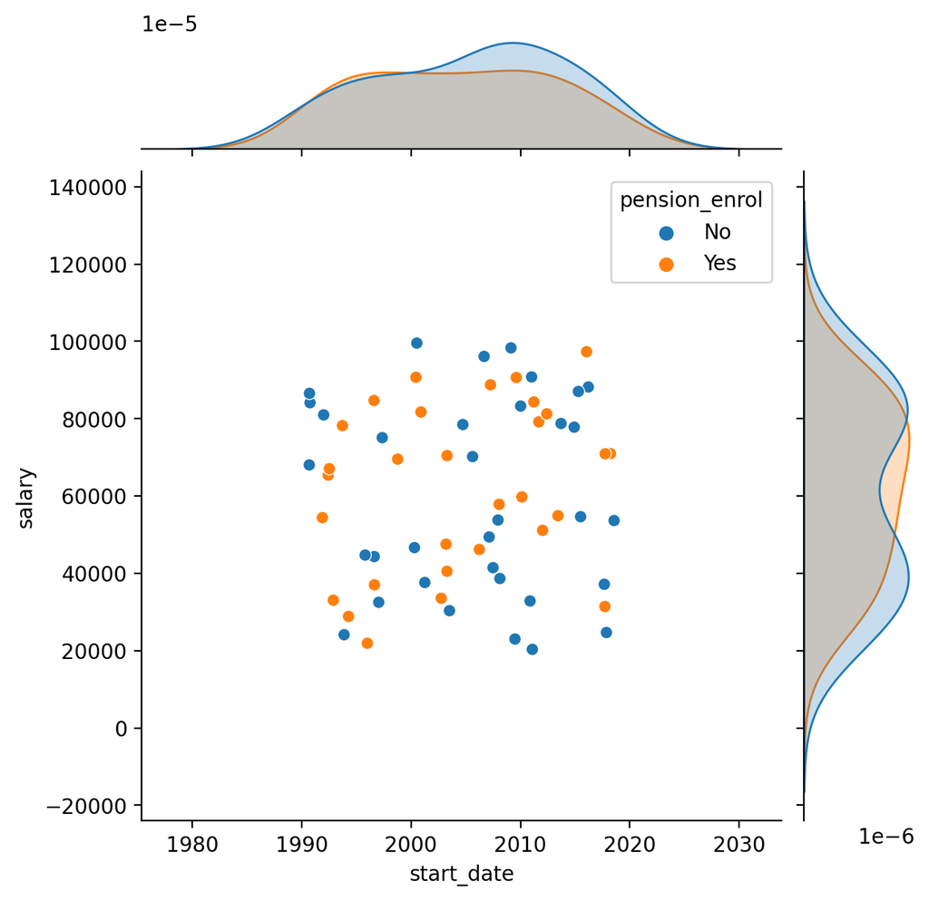

```python
# use .loc[] to select Accounting employees (use .query() above)
scatter = sns.jointplot(
    data=employees.loc[employees.department == 'Accounting'],
    x='start_date',
    y='salary',
    hue = 'pension_enrol'
)
```

The joint plot adds what are called 'densities' to the edges of the plot. These show the distributions of `start_date` and `salary`, and are also split by `hue=` to show any differences due to `pension_enrol`.

# Bar plots and histograms

Bar plots are often used to show total counts of levels of a categorical variable, or sometimes the results of an aggregator function applied to a grouping of rows by categorical level. The `seaborn` package offers a number of functions for categorical visualisation, the simplest being `sns.countplot()`. Let's use this to plot the numbers of employees in each `department`

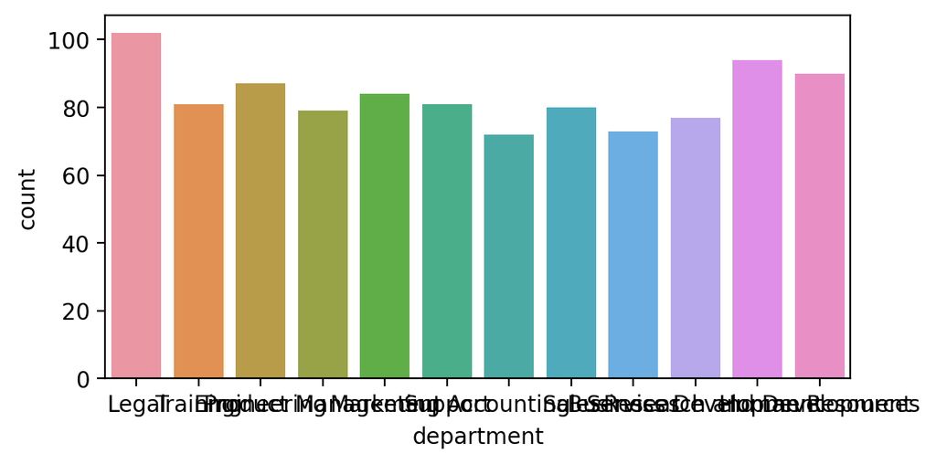

```python
sns.countplot(data=employees, x='department')
```

Looks promising, but the `department` labels overlap each other. Let's rotate them

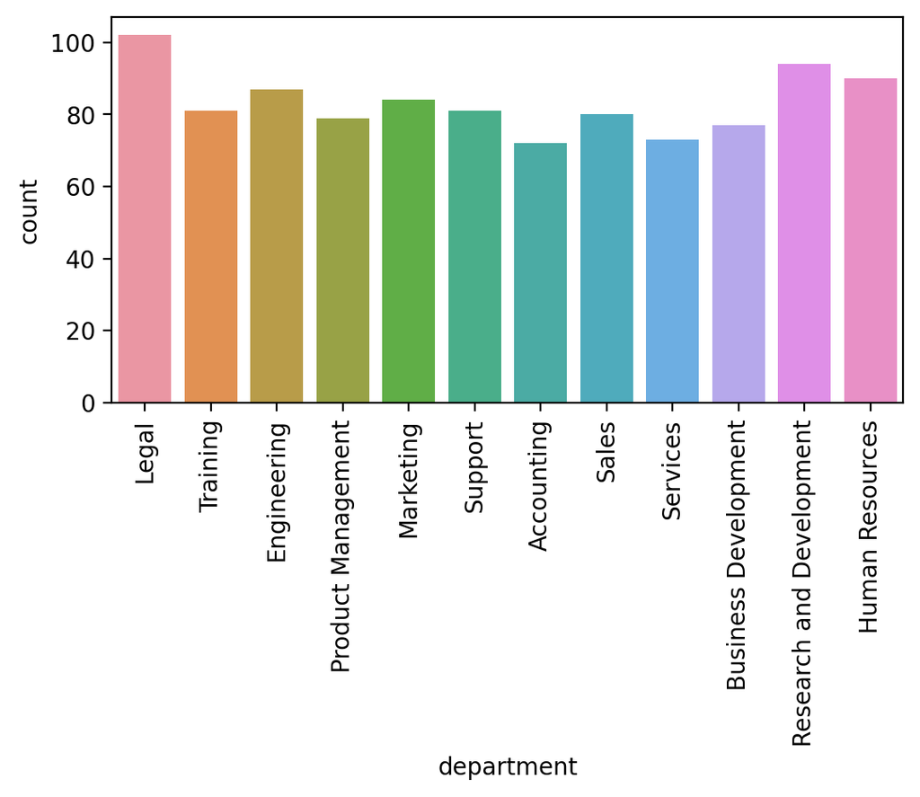

```python
sns.countplot(data=employees, x='department')
# use ; to suppress output of return
plt.xticks(rotation=90);
```

**Task - 2 mins**

Now have a go at running this code:

- What do you think is being plotted on the y-axis?
- What do the black lines at the tops of the bars show?

[**Hint** - it may help to look at the docs for `sns.barplot()`]

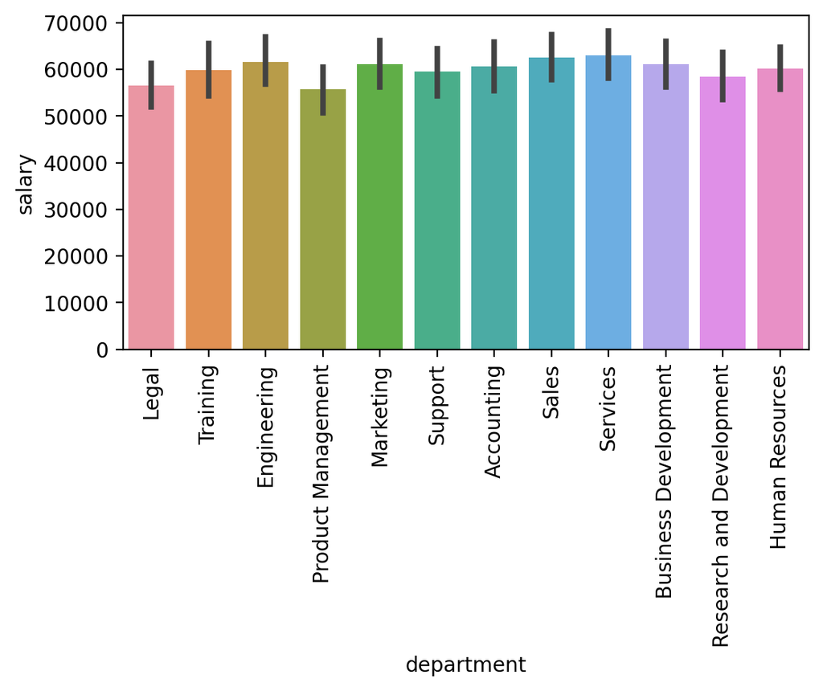

```python
sns.barplot(data=employees, x='department', y='salary')
plt.xticks(rotation=90);
```

**Solution**

The `mean(salary)` is being plotted on the y-axis (`sns.barplot()` defaults to using a mean as its 'estimator'). Each black line shows the 95% 'confidence interval' for the mean: you can interpret this as the likely range for the mean. The longer a particular black line, the more uncertain the mean for that department.

The **histogram** plays a similar role for a continuous variable as the **count plot** does for a categorical variable: count the number of values occurring for each level of the variable.

But what does this mean for a continuous variable? Surely, the problem with a continuous variable is that it is possible for each value in the column to be **unique or close to unique**: a salary of 30,143 is not the same as a salary of 30,144! Well, first the continuous variable is **binned** prior to plotting: `pandas` splits the variable up into discrete 'chunks' (or 'bins') and counts the number of values falling in each chunk:

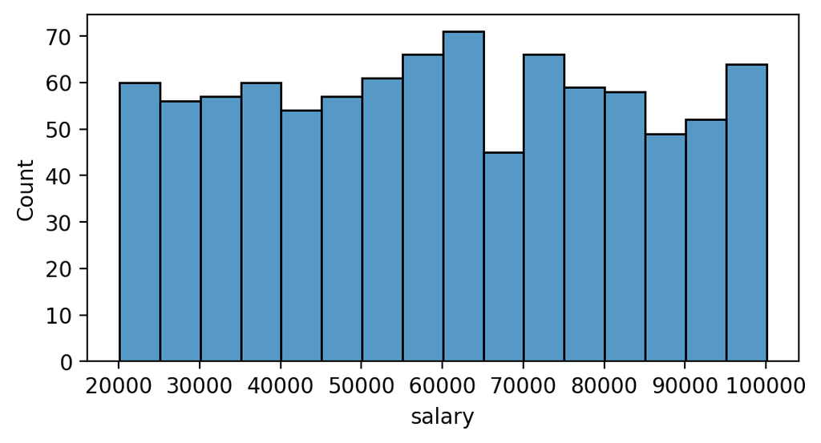

```python
sns.histplot(data=employees, x='salary', binwidth=5000)
```

So, in this plot, the first 'chunk' or bin runs from 20000 to 25000, the second from 25000 to 30000 and so on. The y-axis shows how many salaries lie inside each bin.

# Box plots and violin plots

Box plots, also known as 'box and whisker' plots are commonly used for data exploration, but are less useful in a presentation to non-analysts, as their interpretation is not straightforward (a histogram or series of histograms would be a better choice in this case). They show the distribution of a continuous variable in an 'at a glance' level, and also show data points likely to be outliers.

See **[this link](https://stattrek.com/statistics/charts/boxplot.aspx)** for a description of how to interpret boxplots.

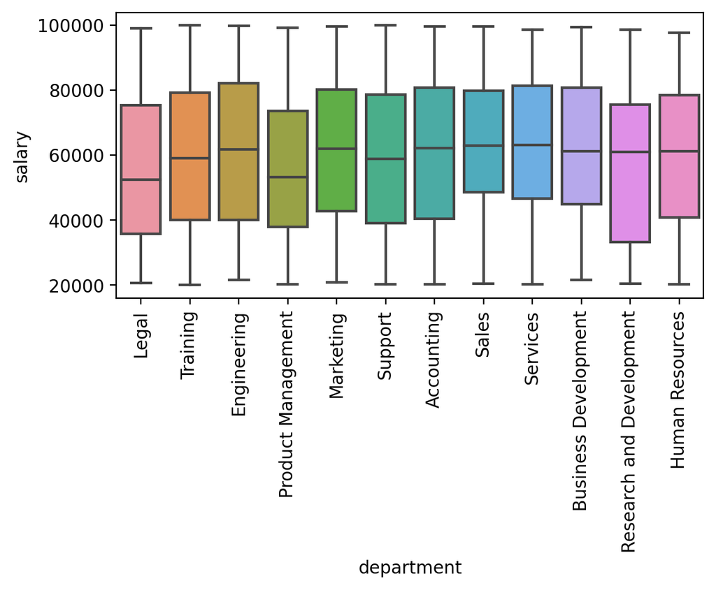

```python
sns.boxplot(data=employees, x='department', y='salary')
plt.xticks(rotation=90);
```

Violin plots might be a better alternative to box plots for an audience who are non-analysts. Within each 'violin' they show the same features as a box plot, but the width of the violin gives an immediate impression of the weight of data lying at that particular y-value. Still, a histogram or series of histograms is arguably a better choice.

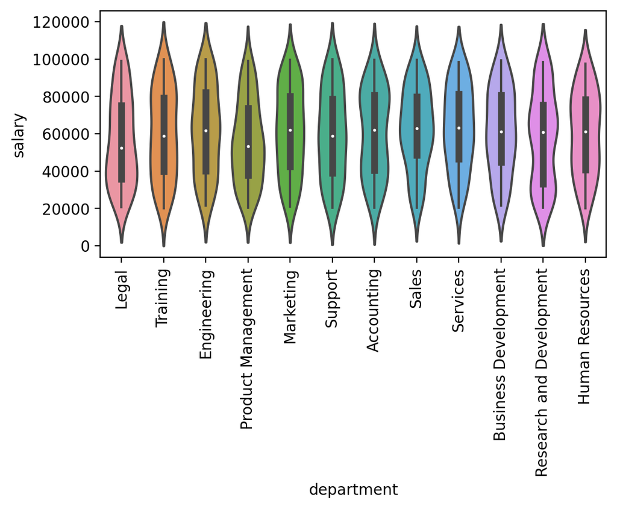

```python
sns.violinplot(x='department', y='salary', data=employees)
plt.xticks(rotation=90);
```

# Saving figures

Saving figures is easy in `seaborn`: we first convert our figure to a conventional `matplotlib` figure using `.get_figure()`, and then we call the `.savefig()` method on that figure. We can control the final DPI, and setting argument `bbox_inches='tight'` lets `matplotlib` figure out what size of bounding box to use around the plot.

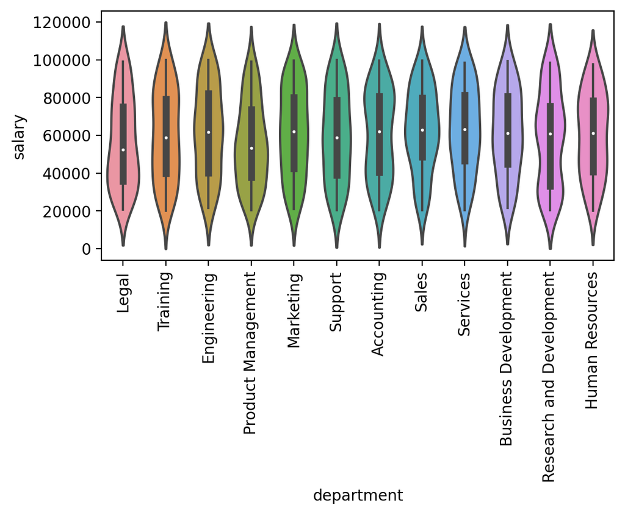

```python
violin = sns.violinplot(x='department', y='salary', data=employees)
plt.xticks(rotation=90);
violin.get_figure().savefig('dept_salary.png', dpi=400, bbox_inches='tight')
```

You should find a file `dept_salary.png` in the same folder as your `jupyter` notebook.

# Optional - Faceting

The ease of creating **faceted plots** is one of the main advantages of `seaborn` over `matplotlib`. What do we mean by 'faceting'? Well, this corresponds to splitting a single plot into two or more sub-plots, typically based on the value of a categorical variable.

Let's see an example. Imagine we want to plot a series of histograms showing the distribution of `salary` in each `department`. We could do this by creating a set of histograms separately, but this is pretty inefficient! How many separate graphs would we need?

```python
employees.department.nunique()
```

```
12
```

A better approach would be to create a **faceted plot**: `seaborn` makes this easy with `FacetGrid()`. First we create a `FacetGrid()` object that holds:

- the `DataFrame` we want to use
- the variable(s) we want to facet on (i.e. create a separate sub-plot for each value of this variable). We can use one or two faceting variables, and we can decide how to distribute these over rows and columns of the sub-plots

Let's see the code for our example. Here we want to facet on `department`, so we set `col='department'` to tell `FacetGrid()` to create one long row of sub-plots, each **column** of the row corresponding to a separate `department`. We also set `col_wrap=3` to tell `FacetGrid()` to wrap the row in units of 3

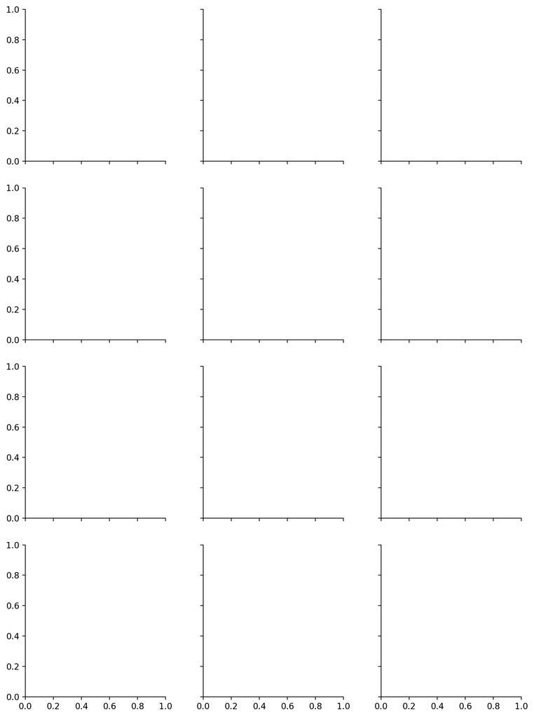

```python
grid = sns.FacetGrid(employees, col='department', col_wrap=3)
```

Neat, it's created the grid three columns wide and four rows tall (remember we asked `FacetGrid()` to wrap at the third column). But the sub-plots are empty! Next we need to tell `seaborn` **what to plot** in each of the facets: we do this with the `.map_dataframe()` method available on the `FacetGrid` object we created above.

In our case, we want to create an `sns.histplot` in each facet, with `x='salary`. After that we do a little tidying up of the plot: setting axis labels and making the facet titles less wordy.

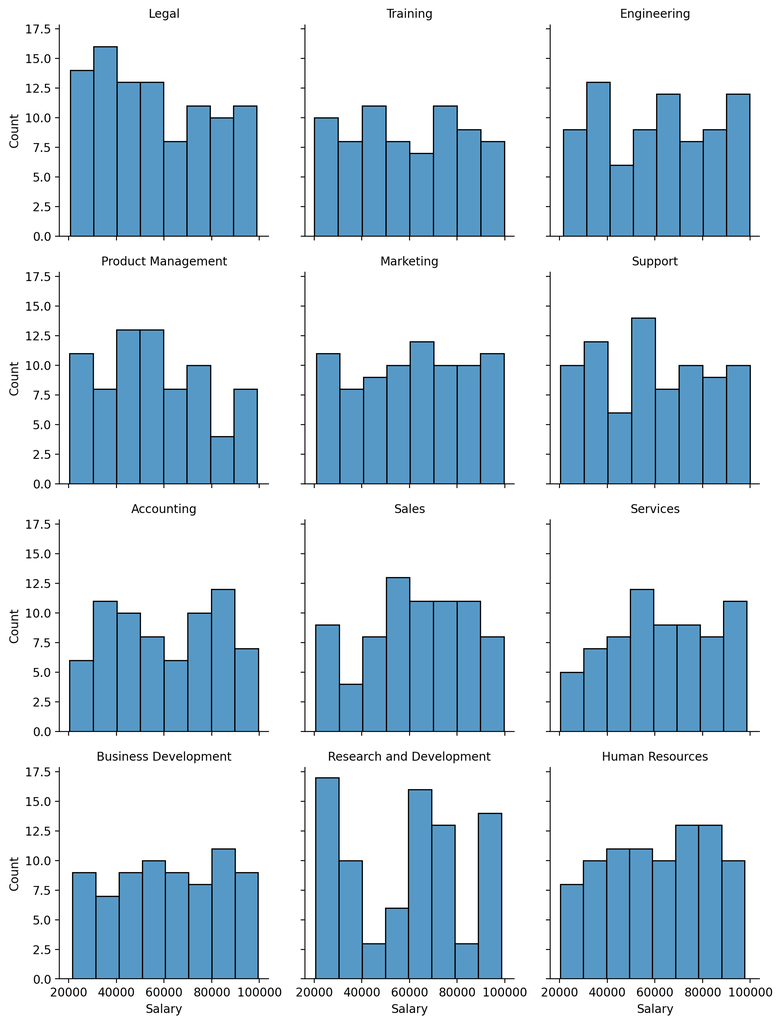

```python
grid.map_dataframe(sns.histplot, x='salary')
grid.set_axis_labels("Salary", "Count")
grid.set_titles('{col_name}')
```

Hopefully this convinces you how useful `seaborn` can be for visualisation! We have only really scratched the surface: there is much more to discover.